# HeartData_EDA

```python
import numpy as np
import pandas as pd
import matplotlib.pyplot as plt
import seaborn as sns
import warnings
warnings.filterwarnings('ignore')
```

```python
heartdf = pd.read_csv('HeartData.csv',na_values=" ")
```

```python
heartdf.head()
```

|  | male | age | education | currentSmoker | cigsPerDay | BPMeds | prevalentStroke | prevalentHyp | diabetes | totChol | sysBP | diaBP | BMI | heartRate | glucose | TenYearCHD |
| --- | --- | --- | --- | --- | --- | --- | --- | --- | --- | --- | --- | --- | --- | --- | --- | --- |
| 0 | 1 | 39 | 4.0 | 0 | 0.0 | 0.0 | 0 | 0 | 0 | 195.0 | 106.0 | 70.0 | 26.97 | 80.0 | 77.0 | 0 |
| 1 | 0 | 46 | 2.0 | 0 | 0.0 | 0.0 | 0 | 0 | 0 | 250.0 | 121.0 | 81.0 | 28.73 | 95.0 | 76.0 | 0 |
| 2 | 1 | 48 | 1.0 | 1 | 20.0 | 0.0 | 0 | 0 | 0 | 245.0 | 127.5 | 80.0 | 25.34 | 75.0 | 70.0 | 0 |
| 3 | 0 | 61 | 3.0 | 1 | 30.0 | 0.0 | 0 | 1 | 0 | 225.0 | 150.0 | 95.0 | 28.58 | 65.0 | 103.0 | 1 |
| 4 | 0 | 46 | 3.0 | 1 | 23.0 | 0.0 | 0 | 0 | 0 | 285.0 | 130.0 | 84.0 | 23.10 | 85.0 | 85.0 | 0 |

#### Data Dictionary

**Demographic:**

1. Sex: male or female(Nominal)
2. Age: Age of the patient;(Continuous - Although the recorded ages have been truncated to whole numbers, the concept of age is continuous)

Behavioral

3. Current Smoker: whether or not the patient is a current smoker (Nominal)
4. Cigs Per Day: the number of cigarettes that the person smoked on average in one day.(can be considered continuous as one can have any number of cigarettes, even half a cigarette.)

**Medical( history):**

1. BP Meds: whether or not the patient was on blood pressure medication (Nominal)
2. Prevalent Stroke: whether or not the patient had previously had a stroke (Nominal)
3. Prevalent Hyp: whether or not the patient was hypertensive (Nominal)
4. Diabetes: whether or not the patient had diabetes (Nominal)

**Medical(current):**

1. Tot Chol: total cholesterol level (Continuous)
2. Sys BP: systolic blood pressure (Continuous)
3. Dia BP: diastolic blood pressure (Continuous)
4. BMI: Body Mass Index (Continuous)
5. Heart Rate: heart rate (Continuous - In medical research, variables such as heart rate though in fact discrete, yet are considered continuous because of large number of possible values.)
6. Glucose: glucose level (Continuous)

**Predict variable (desired target):**

1. 10 year risk of coronary heart disease CHD (binary: “1”, means “Yes”, “0” means “No”)

```python
heartdf.info()
```

```
<class 'pandas.core.frame.DataFrame'>
RangeIndex: 4238 entries, 0 to 4237
Data columns (total 16 columns):
 #   Column           Non-Null Count  Dtype
---  ------           --------------  -----
 0   male             4238 non-null   int64
 1   age              4238 non-null   int64
 2   education        4133 non-null   float64
 3   currentSmoker    4238 non-null   int64
 4   cigsPerDay       4209 non-null   float64
 5   BPMeds           4185 non-null   float64
 6   prevalentStroke  4238 non-null   int64
 7   prevalentHyp     4238 non-null   int64
 8   diabetes         4238 non-null   int64
 9   totChol          4188 non-null   float64
 10  sysBP            4238 non-null   float64
 11  diaBP            4238 non-null   float64
 12  BMI              4219 non-null   float64
 13  heartRate        4237 non-null   float64
 14  glucose          3850 non-null   float64
 15  TenYearCHD       4238 non-null   int64
dtypes: float64(9), int64(7)
memory usage: 529.9 KB
```

```python
heartdf.describe()
```

|  | male | age | education | currentSmoker | cigsPerDay | BPMeds | prevalentStroke | prevalentHyp | diabetes | totChol | sysBP | diaBP | BMI | heartRate | glucose | TenYearCHD |
| --- | --- | --- | --- | --- | --- | --- | --- | --- | --- | --- | --- | --- | --- | --- | --- | --- |
| count | 4238.000000 | 4238.000000 | 4133.000000 | 4238.000000 | 4209.000000 | 4185.000000 | 4238.000000 | 4238.000000 | 4238.000000 | 4188.000000 | 4238.000000 | 4238.000000 | 4219.000000 | 4237.000000 | 3850.000000 | 4238.000000 |
| mean | 0.429212 | 49.584946 | 1.978950 | 0.494101 | 9.003089 | 0.029630 | 0.005899 | 0.310524 | 0.025720 | 236.721585 | 132.352407 | 82.893464 | 25.802008 | 75.878924 | 81.966753 | 0.151958 |
| std | 0.495022 | 8.572160 | 1.019791 | 0.500024 | 11.920094 | 0.169584 | 0.076587 | 0.462763 | 0.158316 | 44.590334 | 22.038097 | 11.910850 | 4.080111 | 12.026596 | 23.959998 | 0.359023 |
| min | 0.000000 | 32.000000 | 1.000000 | 0.000000 | 0.000000 | 0.000000 | 0.000000 | 0.000000 | 0.000000 | 107.000000 | 83.500000 | 48.000000 | 15.540000 | 44.000000 | 40.000000 | 0.000000 |
| 25% | 0.000000 | 42.000000 | 1.000000 | 0.000000 | 0.000000 | 0.000000 | 0.000000 | 0.000000 | 0.000000 | 206.000000 | 117.000000 | 75.000000 | 23.070000 | 68.000000 | 71.000000 | 0.000000 |
| 50% | 0.000000 | 49.000000 | 2.000000 | 0.000000 | 0.000000 | 0.000000 | 0.000000 | 0.000000 | 0.000000 | 234.000000 | 128.000000 | 82.000000 | 25.400000 | 75.000000 | 78.000000 | 0.000000 |
| 75% | 1.000000 | 56.000000 | 3.000000 | 1.000000 | 20.000000 | 0.000000 | 0.000000 | 1.000000 | 0.000000 | 263.000000 | 144.000000 | 89.875000 | 28.040000 | 83.000000 | 87.000000 | 0.000000 |
| max | 1.000000 | 70.000000 | 4.000000 | 1.000000 | 70.000000 | 1.000000 | 1.000000 | 1.000000 | 1.000000 | 696.000000 | 295.000000 | 142.500000 | 56.800000 | 143.000000 | 394.000000 | 1.000000 |

### Simple data exploration, Missing Value Check & Handling Duplicate Values

```python
heartdf.shape
```

```
(4238, 16)
```

```python
heartdf.isnull().sum()
```

```
male                 0
age                  0
education          105
currentSmoker        0
cigsPerDay          29
BPMeds              53
prevalentStroke      0
prevalentHyp         0
diabetes             0
totChol             50
sysBP                0
diaBP                0
BMI                 19
heartRate            1
glucose            388
TenYearCHD           0
dtype: int64
```

```python
heartdf.duplicated().sum()
```

```
0
```

### Identifying Outliers for all the columns

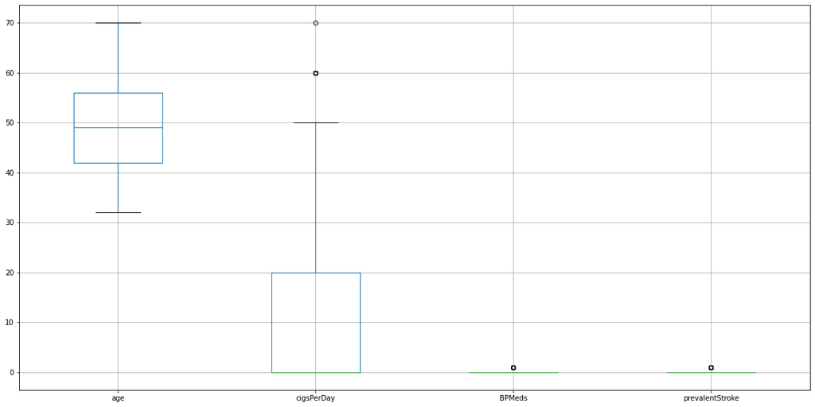

```python
plt.figure(figsize=(20, 10))
heartdf[["age","cigsPerDay","BPMeds","prevalentStroke"]].boxplot()
```

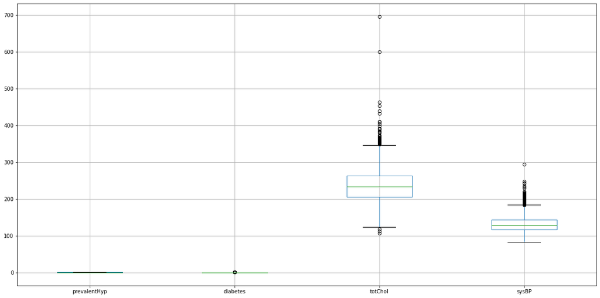

```python
plt.figure(figsize=(20, 10))
heartdf[["prevalentHyp","diabetes","totChol","sysBP"]].boxplot()
```

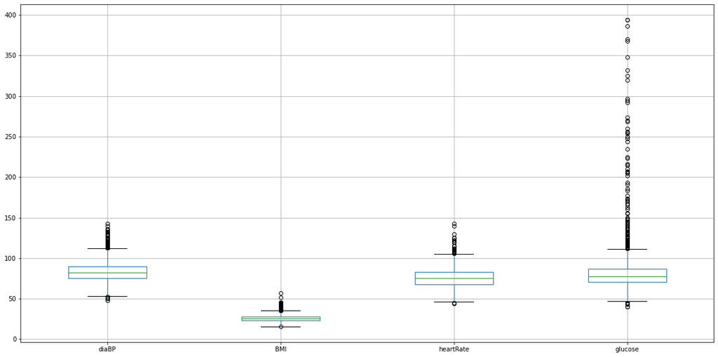

```python
plt.figure(figsize=(20, 10))
heartdf[["diaBP","BMI","heartRate","glucose"]].boxplot()
```

### Individual Features Exploration

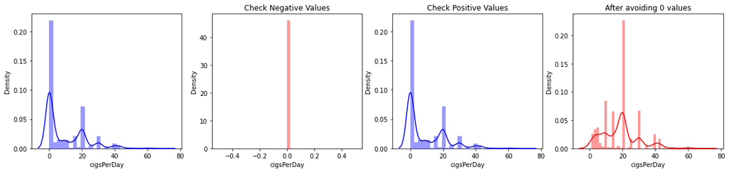

```python
f, (ax1,ax2,ax3,ax4) = plt.subplots(1,4,figsize=(20,4))
sns.distplot(heartdf['cigsPerDay'],color='b',ax=ax1)
sns.distplot(heartdf[heartdf['cigsPerDay']<=0]['cigsPerDay'], color="r", ax=ax2)
ax2.set_title('Check Negative Values')
sns.distplot(heartdf[heartdf['cigsPerDay']>=0]['cigsPerDay'],color='b',ax=ax3)
ax3.set_title('Check Positive Values')
sns.distplot(heartdf[heartdf['cigsPerDay']!=0]['cigsPerDay'],color='r',ax=ax4)
ax4.set_title('After avoiding 0 values')
```

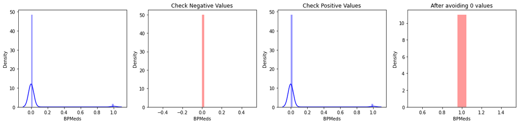

```python
f, (ax1,ax2,ax3,ax4) = plt.subplots(1,4,figsize=(20,4))
sns.distplot(heartdf['BPMeds'],color='b',ax=ax1)
sns.distplot(heartdf[heartdf['BPMeds']<=0]['BPMeds'], color="r", ax=ax2)
ax2.set_title('Check Negative Values')
sns.distplot(heartdf[heartdf['BPMeds']>=0]['BPMeds'],color='b',ax=ax3)
ax3.set_title('Check Positive Values')
sns.distplot(heartdf[heartdf['BPMeds']!=0]['BPMeds'],color='r',ax=ax4)
ax4.set_title('After avoiding 0 values')
```

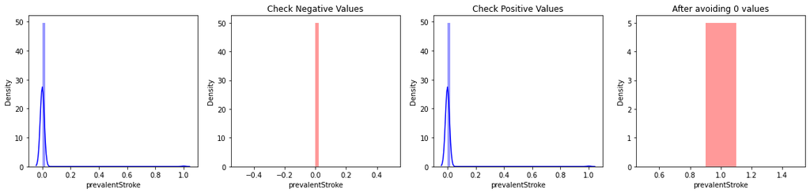

```python
f, (ax1,ax2,ax3,ax4) = plt.subplots(1,4,figsize=(20,4))
sns.distplot(heartdf['prevalentStroke'],color='b',ax=ax1)
sns.distplot(heartdf[heartdf['prevalentStroke']<=0]['prevalentStroke'], color="r", ax=ax2)
ax2.set_title('Check Negative Values')
sns.distplot(heartdf[heartdf['prevalentStroke']>=0]['prevalentStroke'],color='b',ax=ax3)
ax3.set_title('Check Positive Values')
sns.distplot(heartdf[heartdf['prevalentStroke']!=0]['prevalentStroke'],color='r',ax=ax4)
ax4.set_title('After avoiding 0 values')
```

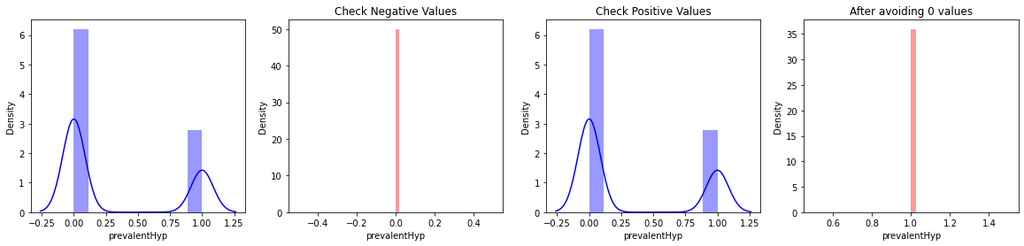

```python
f, (ax1,ax2,ax3,ax4) = plt.subplots(1,4,figsize=(20,4))
sns.distplot(heartdf['prevalentHyp'],color='b',ax=ax1)
sns.distplot(heartdf[heartdf['prevalentHyp']<=0]['prevalentHyp'], color="r", ax=ax2)
ax2.set_title('Check Negative Values')
sns.distplot(heartdf[heartdf['prevalentHyp']>=0]['prevalentHyp'],color='b',ax=ax3)
ax3.set_title('Check Positive Values')
sns.distplot(heartdf[heartdf['prevalentHyp']!=0]['prevalentHyp'],color='r',ax=ax4)
ax4.set_title('After avoiding 0 values')
```

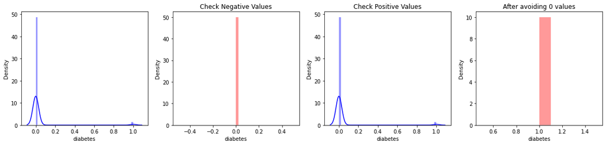

```python
f, (ax1,ax2,ax3,ax4) = plt.subplots(1,4,figsize=(20,4))
sns.distplot(heartdf['diabetes'],color='b',ax=ax1)
sns.distplot(heartdf[heartdf['diabetes']<=0]['diabetes'], color="r", ax=ax2)
ax2.set_title('Check Negative Values')
sns.distplot(heartdf[heartdf['diabetes']>=0]['diabetes'],color='b',ax=ax3)
ax3.set_title('Check Positive Values')
sns.distplot(heartdf[heartdf['diabetes']!=0]['diabetes'],color='r',ax=ax4)
ax4.set_title('After avoiding 0 values')
```

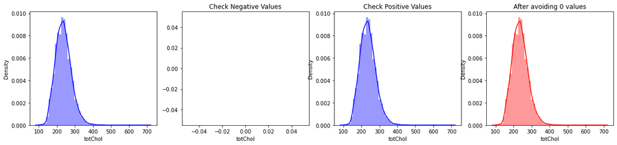

```python
f, (ax1,ax2,ax3,ax4) = plt.subplots(1,4,figsize=(20,4))
sns.distplot(heartdf['totChol'],color='b',ax=ax1)
sns.distplot(heartdf[heartdf['totChol']<=0]['totChol'], color="r", ax=ax2)
ax2.set_title('Check Negative Values')
sns.distplot(heartdf[heartdf['totChol']>=0]['totChol'],color='b',ax=ax3)
ax3.set_title('Check Positive Values')
sns.distplot(heartdf[heartdf['totChol']!=0]['totChol'],color='r',ax=ax4)
ax4.set_title('After avoiding 0 values')
```

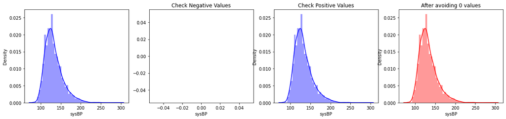

```python
f, (ax1,ax2,ax3,ax4) = plt.subplots(1,4,figsize=(20,4))
sns.distplot(heartdf['sysBP'],color='b',ax=ax1)
sns.distplot(heartdf[heartdf['sysBP']<=0]['sysBP'], color="r", ax=ax2)
ax2.set_title('Check Negative Values')
sns.distplot(heartdf[heartdf['sysBP']>=0]['sysBP'],color='b',ax=ax3)
ax3.set_title('Check Positive Values')
sns.distplot(heartdf[heartdf['sysBP']!=0]['sysBP'],color='r',ax=ax4)
ax4.set_title('After avoiding 0 values')
```

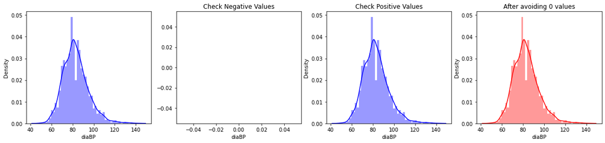

```python
f, (ax1,ax2,ax3,ax4) = plt.subplots(1,4,figsize=(20,4))
sns.distplot(heartdf['diaBP'],color='b',ax=ax1)
sns.distplot(heartdf[heartdf['diaBP']<=0]['diaBP'], color="r", ax=ax2)
ax2.set_title('Check Negative Values')
sns.distplot(heartdf[heartdf['diaBP']>=0]['diaBP'],color='b',ax=ax3)
ax3.set_title('Check Positive Values')
sns.distplot(heartdf[heartdf['diaBP']!=0]['diaBP'],color='r',ax=ax4)
ax4.set_title('After avoiding 0 values')
```

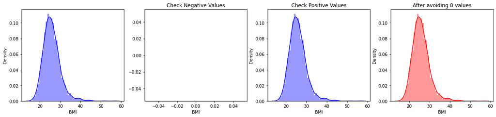

```python
f, (ax1,ax2,ax3,ax4) = plt.subplots(1,4,figsize=(20,4))
sns.distplot(heartdf['BMI'],color='b',ax=ax1)
sns.distplot(heartdf[heartdf['BMI']<=0]['BMI'], color="r", ax=ax2)
ax2.set_title('Check Negative Values')
sns.distplot(heartdf[heartdf['BMI']>=0]['BMI'],color='b',ax=ax3)
ax3.set_title('Check Positive Values')
sns.distplot(heartdf[heartdf['BMI']!=0]['BMI'],color='r',ax=ax4)
ax4.set_title('After avoiding 0 values')
```

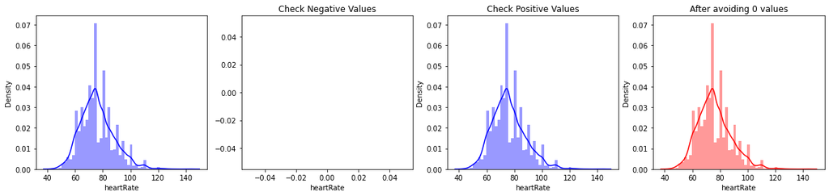

```python
f, (ax1,ax2,ax3,ax4) = plt.subplots(1,4,figsize=(20,4))
sns.distplot(heartdf['heartRate'],color='b',ax=ax1)
sns.distplot(heartdf[heartdf['heartRate']<=0]['heartRate'], color="r", ax=ax2)
ax2.set_title('Check Negative Values')
sns.distplot(heartdf[heartdf['heartRate']>=0]['heartRate'],color='b',ax=ax3)
ax3.set_title('Check Positive Values')
sns.distplot(heartdf[heartdf['heartRate']!=0]['heartRate'],color='r',ax=ax4)
ax4.set_title('After avoiding 0 values')
```

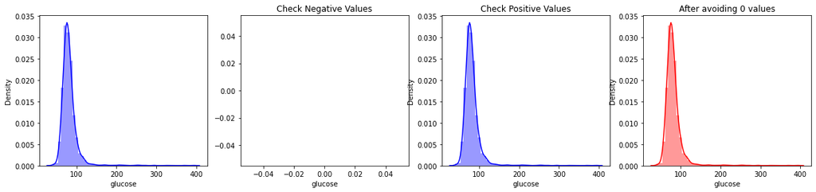

```python
f, (ax1,ax2,ax3,ax4) = plt.subplots(1,4,figsize=(20,4))
sns.distplot(heartdf['glucose'],color='b',ax=ax1)
sns.distplot(heartdf[heartdf['glucose']<=0]['glucose'], color="r", ax=ax2)
ax2.set_title('Check Negative Values')
sns.distplot(heartdf[heartdf['glucose']>=0]['glucose'],color='b',ax=ax3)
ax3.set_title('Check Positive Values')
sns.distplot(heartdf[heartdf['glucose']!=0]['glucose'],color='r',ax=ax4)
ax4.set_title('After avoiding 0 values')
```

### Feature to feature relationship

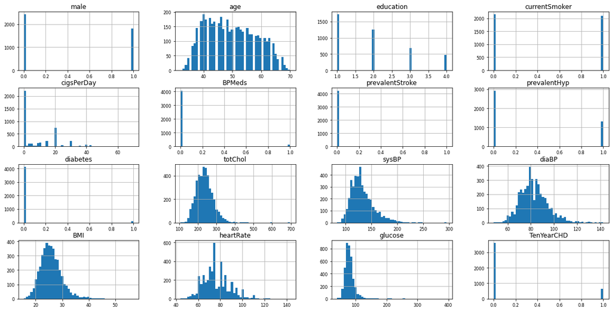

```python
heartdf.hist(figsize=(20, 10), bins=50, xlabelsize=8, ylabelsize=8);
```

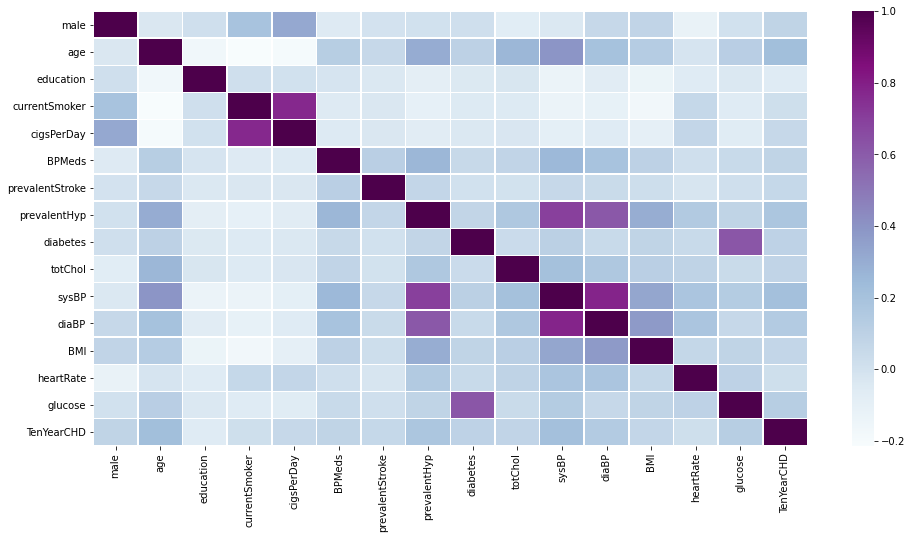

```python
plt.figure(figsize=(16, 8))
corr = heartdf.corr()
ax = sns.heatmap(corr, linewidth=0.5,cmap='BuPu')
plt.show()
```

```python
heartdf.to_excel("heartdata.xlsx", index=False)
```